# Quant Methods - Time Series 3 - Timezones, reading files with dates

**Datetime and time zones**

```r
n = Sys.time()
print(n)
```

```
[1] "2021-09-17 10:47:39 EDT"
```

```r
as.numeric(n)
```

```
[1] 1631890059
```

Seconds since 1 Jan 1970 UTC What if we want the time in GMT (or UTC) rather than EST? Use with_tz()

```r
ngmt = with_tz(n,tzone="GMT")
print(ngmt)
```

```
[1] "2021-09-17 14:47:39 GMT"
```

So this converts the time to the equivalent time in GMT. For US, accepted time zones designators include: EST5EDT, CST6CDT, MST7MDT, PST8PDT Also name conventions like: America/Chicago, America/New_York [Can see list if type OlsonNames()]

```r
npdf = with_tz(n,tzone="PST8PDT")
print(npdf)
```

```
[1] "2021-09-17 07:47:39 PDT"
```

What if we read in a time as EST or EDT but it really should be UTC? E.g., 0 date for POSIX time Use force_tz()

```r
t0 = as.POSIXct("1970-01-01 00:00")
print(t0)
```

```
[1] "1970-01-01 EST"
```

```r
t0 = force_tz(t0,tzone="GMT")
print(t0)
```

```
[1] "1970-01-01 GMT"
```

```r
as.numeric(t0)
```

```
[1] 0
```

**Reading dates from files**

Let’s try reading in a file with date and time. The Miss R discharge csv we looked at last week had a date-time column.

```r
Qdf = read.csv("USGSMissRDischargeAug2021.csv")
```

The date-time format in this file is “8/27/21 0:00” So we would use the mdy format in lubridate to read in the date. How do we indicate time? mdy_hm

```r
Qdf$DT = mdy_hm(Qdf$DateTime)

print(Qdf$DT[1:3])
```

```
[1] "2021-08-27 00:00:00 UTC" "2021-08-27 00:15:00 UTC"
[3] "2021-08-27 00:30:00 UTC"
```

```r
print(Qdf$DT[1])
```

```
[1] "2021-08-27 UTC"
```

Okay, looks good. But are the data reported in UTC? No - time are local time (CDT).

```r
Qdf$DT = force_tz(mdy_hm(Qdf$DateTime), tzone="CST6CDT")
print(Qdf$DT[1:3])
```

```
[1] "2021-08-27 00:00:00 CDT" "2021-08-27 00:15:00 CDT"
[3] "2021-08-27 00:30:00 CDT"
```

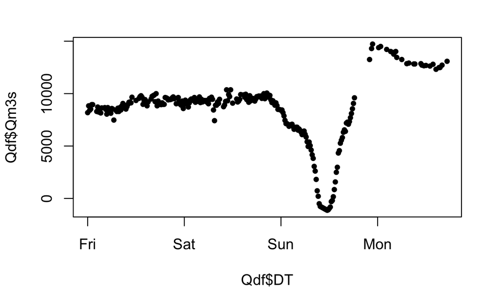

```r
Qdf$Qm3s = Qdf$Qcfs * (0.3048^3)
plot(Qdf$DT, Qdf$Qm3s, pch = 20)
```

We know there are missing values. Let’s make a complete time vector.

```r
t1 = Qdf$DT[1]
t2 = Qdf$DT[length(Qdf$DT)]
tfull = seq.POSIXt(t1, t2, by = "15 min")
print(tfull[1:10])
```

```
 [1] "2021-08-27 00:00:00 CDT" "2021-08-27 00:15:00 CDT"
 [3] "2021-08-27 00:30:00 CDT" "2021-08-27 00:45:00 CDT"
 [5] "2021-08-27 01:00:00 CDT" "2021-08-27 01:15:00 CDT"
 [7] "2021-08-27 01:30:00 CDT" "2021-08-27 01:45:00 CDT"
 [9] "2021-08-27 02:00:00 CDT" "2021-08-27 02:15:00 CDT"
```

```r
length(tfull)
```

```
[1] 358
```

```r
length(Qdf$DT)
```

```
[1] 270
```

There are clearly many values missing. Spread out over record or all together? We can use diff() to answer that question. diff() takes difference between successive values.

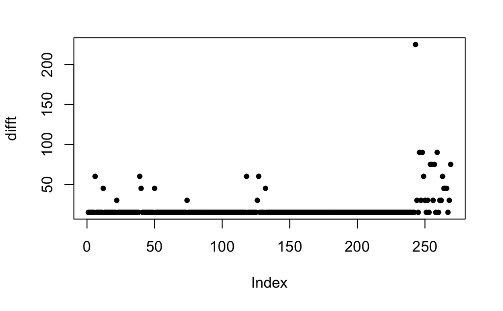

```r
difft = diff(Qdf$DT)
plot(difft, pch=20)
```

So mostly missing values are spread out but there is a ~3-hr gap near the end.

One thing I like to do is in datasets with missing values is to add all the missing times (with NA for value). Why? Better for comparing records, among other things.

We can do this with a function in the package dplyr called left_join().

Install dplyr

```r
library(dplyr)
```

The left_join(x,y,by=“..”) function “adds columns from y to x, matching rows based on the keys [column name(s) in by = ]; left_join() includes all rows in x”

left_join() wants x and y to be data frames, so let’s make tfull into a data frame. And the columns to be merged must have IDENTICAL names

```r
QFdf = data.frame(tfull)
colnames(QFdf) = c("DTCDT")
colnames(Qdf)[8] = c("DTCDT")
```

Now use left_join(QFdf, Qdf, by=“DTCDT”).

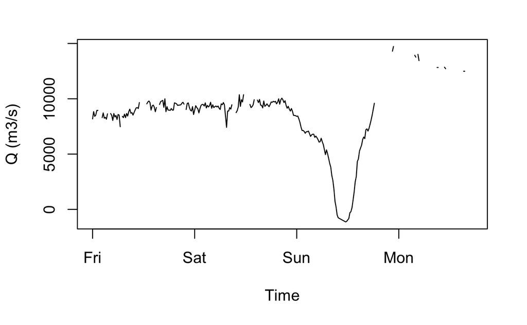

```r
QNdf = left_join(QFdf, Qdf, by="DTCDT")
plot(QNdf$DTCDT, QNdf$Qm3s, type="l", ylab="Q (m3/s)", xlab="Time")
```

We can save this new file if we want.

```r
write.csv(QNdf,"MissRDischargeAug2021Full.csv")
```